# Regresja Nieliniowa - Zadania

2026-02-10

Dawid Sporysiak

# Zadanie 1+2

```r
data(methionine)
head(methionine)
```

```
##   product dose gain
## 1 control 0.00 1453
## 2     DLM 0.04 1593
## 3     DLM 0.09 1660
## 4     DLM 0.15 1666
## 5     DLM 0.22 1698
## 7     MHA 0.04 1561
```

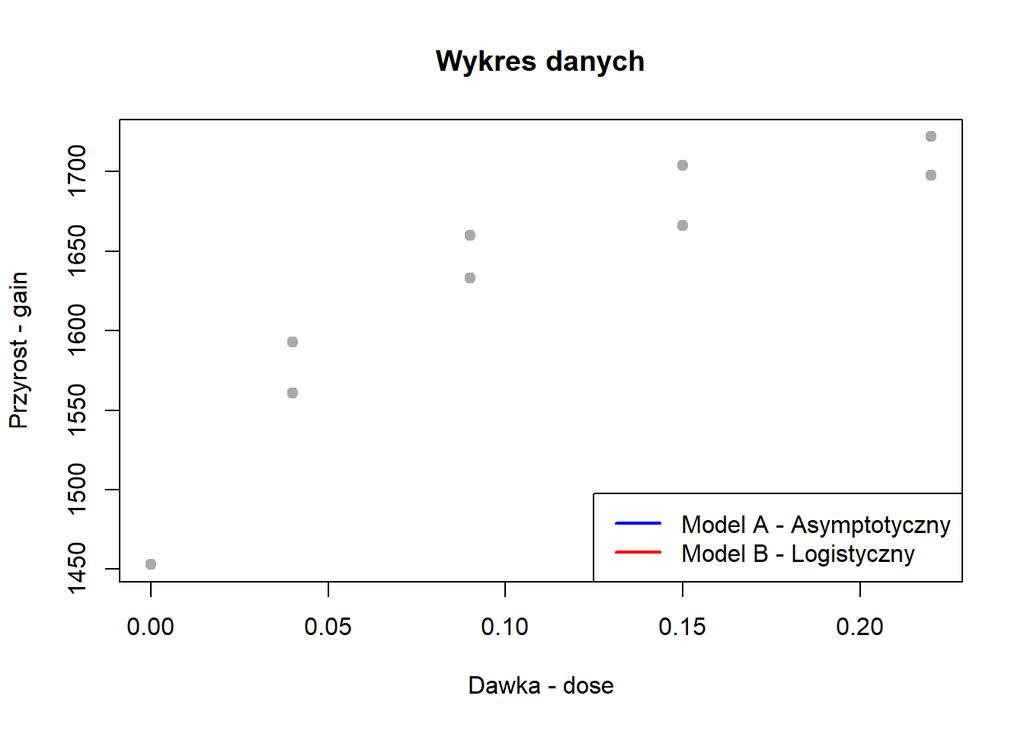

```r
plot(methionine$dose, methionine$gain, pch = 19, col = "darkgray",
     main = "Wykres danych", xlab = "Dawka - dose", ylab = "Przyrost - gain")
legend("bottomright", legend = c("Model A - Asymptotyczny", "Model B - Logistyczny"),
       col = c("blue", "red"), lwd = 2)
```

Dane są nieliniowe, tzn ich układ przypomina logarytm albo pierwiastek, nie można zastosować przybliżania funkcją liniową, ponieważ MSE byłby zbyt duży.

# Model A

b1 oszacowane z wykresu (około 1450), b2 około 1700, b3 testowane wieeele razy.

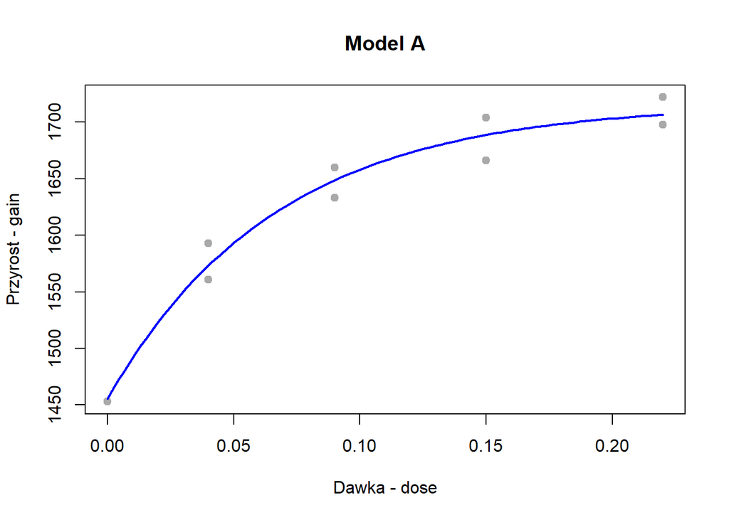

```r
m_a = nls(gain ~ b1 + (b2 - b1) * (1 - exp(-b3 * dose)), data = methionine, start = list(b1 = 1450, b2 = 1700, b3 = 15))

plot(methionine$dose, methionine$gain, pch = 19, col = "darkgray",
     main = "Model A", xlab = "Dawka - dose", ylab = "Przyrost - gain")
curve(predict(m_a, data.frame(dose = x)), add = TRUE, col = "blue", lwd = 2)
```

```r
summary(m_a)
```

```
##
## Formula: gain ~ b1 + (b2 - b1) * (1 - exp(-b3 * dose))
##
## Parameters:
##    Estimate Std. Error t value Pr(>|t|)
## b1 1455.472     17.480  83.264 2.02e-10 ***
## b2 1716.149     16.121 106.453 4.63e-11 ***
## b3   15.022      3.028   4.961  0.00255 **
## ---
## Signif. codes:  0 '***' 0.001 '**' 0.01 '*' 0.05 '.' 0.1 ' ' 1
##
## Residual standard error: 18.18 on 6 degrees of freedom
##
## Number of iterations to convergence: 2
## Achieved convergence tolerance: 3.254e-06
```

nls poprawił wartości b1 na 1455.472, b2 na 1716.149, i b3 na 15.022. RSE=18.18.

# Model B

b3 oszacowane z wykresu, b1 i b2 analogicznie jak b3 powyżej.

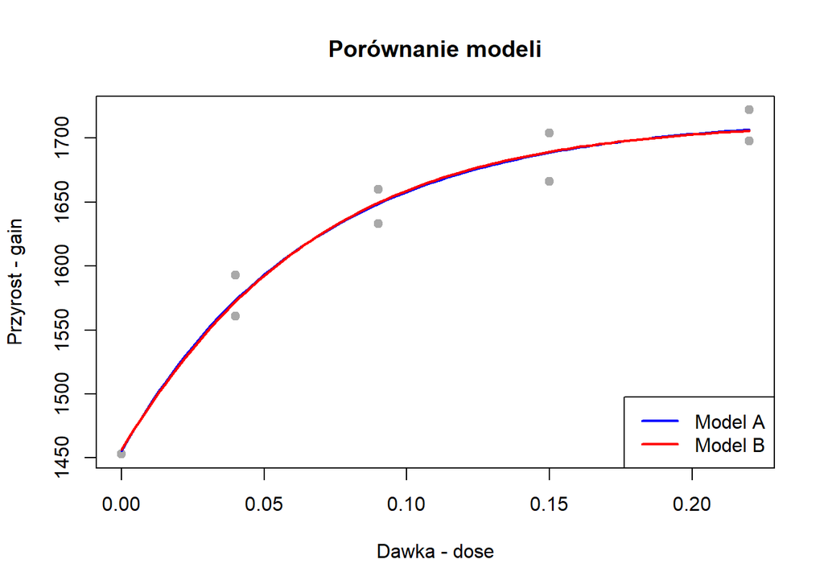

```r
m_b = nls(gain ~ b3 / (1 + exp(b1 + b2 * dose)), data = methionine, start = list(b1 = -2, b2 = -15, b3 = 1700))

#Wykres
plot(methionine$dose, methionine$gain, pch = 19, col = "darkgray",
     main = "Porównanie modeli", xlab = "Dawka - dose", ylab = "Przyrost - gain")
curve(predict(m_a, data.frame(dose = x)), add = TRUE, col = "blue", lwd = 2)
curve(predict(m_b, data.frame(dose = x)), add = TRUE, col = "red", lwd = 2)
legend("bottomright", legend = c("Model A", "Model B"), col = c("blue", "red"), lwd = 2)
```

```r
summary(m_b)
```

```
##
## Formula: gain ~ b3/(1 + exp(b1 + b2 * dose))
##
## Parameters:
##      Estimate Std. Error t value Pr(>|t|)
## b1   -1.73621    0.08634 -20.108 9.82e-07 ***
## b2  -16.89654    3.23496  -5.223  0.00197 **
## b3 1713.03248   15.02541 114.009 3.07e-11 ***
## ---
## Signif. codes:  0 '***' 0.001 '**' 0.01 '*' 0.05 '.' 0.1 ' ' 1
##
## Residual standard error: 18.44 on 6 degrees of freedom
##
## Number of iterations to convergence: 5
## Achieved convergence tolerance: 9.81e-07
```

nls poprawił wartości b1 na -1.73621, b2 na -16.89654, i b3 na 1713.03248. RSE=18.44.

```r
n = nrow(methionine)

#MSE dla A
rss_a = sum(resid(m_a)^2)
mse_a = rss_a / n
cat("MSE dla A:", mse_a)
```

```
## MSE dla A: 220.3054
```

```r
#MSE dla B
rss_b = sum(resid(m_b)^2)
mse_b = rss_b / n
cat("\nMSE dla B:", mse_b)
```

```
##
## MSE dla B: 226.6285
```

W obu przypadkach i z MSE i RSE mniejszy błąd jest dla modelu A, więc jest on lepiej dopasowany dla istniejących danych. Graficznie różnica istnieje, ale na oko jest ona niezauważalna pod względem ‘która jest lepsza’. są po prostu bardzo podobne.

# Zadanie 3

```r
mod_loess = loess(gain ~ dose, data = methionine)
#RSS (nieparametryczne, więc nie będzie tutaj żadnych parametrów podawanych)
RSS_loess = sum(mod_loess$residuals^2)
cat("RSS dla LOESS:", RSS_loess)
```

```
## RSS dla LOESS: 1886.5
```

# Spliny

```r
mod_spline = smooth.spline(methionine$dose, methionine$gain)
#RSS między faktycznym, a wyliczonym przez spliny
y_pred_spline = predict(mod_spline, methionine$dose)$y
RSS_spline = sum((methionine$gain - y_pred_spline)^2)
cat("RSS dla Splinów:", RSS_spline)
```

```
## RSS dla Splinów: 2348.383
```

Model poradził sobie gorzej niż LOESS.

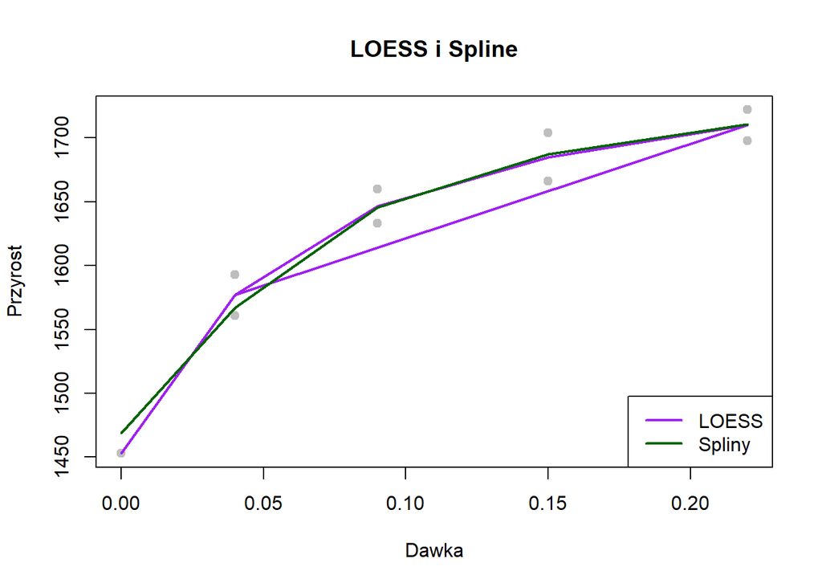

```r
plot(methionine$dose, methionine$gain, pch = 19, col = "grey",
     main = "LOESS i Spline", xlab = "Dawka", ylab = "Przyrost")
lines(methionine$dose, predict(mod_loess), col = "purple", lwd = 2)
lines(mod_spline, col = "darkgreen", lwd = 2)
legend("bottomright", legend = c("LOESS", "Spliny"), col = c("purple", "darkgreen"), lwd = 2)
```

Loess stworzył 2 linie na wykresie, RSE policzone jest dobrze, ale źle narysowane, przez kolejność danych (linia złączyła slę dla jednego punktu jako wejście i wyjście, ważna jest ta górna).

# Zadanie 4

```r
modelA_init = function(mCall, LHS, data) {
  xy = sortedXyData(mCall[["dose"]], LHS, data)
  b1 = min(xy$y)
  b2 = max(xy$y)
  b3 = 10
  value = c(b1, b2, b3)
  names(value) = c("b1", "b2", "b3")
  return(value)
}
SSmodelA = selfStart(~ b1 + (b2 - b1) * (1 - exp(-b3 * dose)), initial = modelA_init, parameters = c("b1", "b2", "b3"))
model_test = nls(gain ~ SSmodelA(dose, b1, b2, b3), data = methionine)
summary(model_test)
```

```
##
## Formula: gain ~ SSmodelA(dose, b1, b2, b3)
##
## Parameters:
##    Estimate Std. Error t value Pr(>|t|)
## b1 1455.472     17.480  83.264 2.02e-10 ***
## b2 1716.149     16.121 106.454 4.63e-11 ***
## b3   15.022      3.028   4.961  0.00255 **
## ---
## Signif. codes:  0 '***' 0.001 '**' 0.01 '*' 0.05 '.' 0.1 ' ' 1
##
## Residual standard error: 18.18 on 6 degrees of freedom
##
## Number of iterations to convergence: 4
## Achieved convergence tolerance: 1.139e-06
```

B1: 1455.472, B2: 1716.149, B3: 15.022, RSE: 18.18 Wartości są identyczne jak w modelu A, więc obie funkcje znalażły to samo ‘optymalne’ rowziązanie.

# Zadanie 5

```r
bledy = c()

#pętla n razy dla krosswalidacji n-krotnej
for(i in 1:n) {
  #LOOCV
  m = nls(gain ~ SSmodelA(dose, b1, b2, b3), data = methionine[-i,])
  #i-ty błąd ((y) rzecziwisty - przewidziany)^2
  bledy[i] = (methionine$gain[i] - predict(m, methionine[i,]))^2
}
RSS_CV = sum(bledy)
cat("Wynik kroswalidacji:", RSS_CV)
```

```
## Wynik kroswalidacji: 4494.492
```

Błąd jest dużo większy, ponieważ usunięcie jednego punktu ze zbioru danych zawierającego ich 9 ma bardzo duży wpływ na wartości błędu. Największe znaczenie miał tam 1 punkt, bo był najdalej oddalony od pozostałyhc, wpływającmocno na wartości.